# MATH545-A1-Q5

Christopher Zheng

30/01/2020

```r
library(readxl) # You may need to install this package first
library(tidyverse)
library(fpp2)
library(knitr)
library(tsbox)
library(gridExtra)
library(tibbletime)
sales_data <- read_excel("Assign1Q5_sales.xlsx")
library(forecast) # You may need to install this package first
sales_ts <- ts(sales_data, frequency=13) # Because there are
# 13 4-week periods per year
#length(sales_ts[1])
```

##### (a) First plot and describe the time series. Note any perceived trend and seasonal components. Do you believe that the sales data series is a stationary series? Explain your answer. Hint: You may want to use an ACF plot.

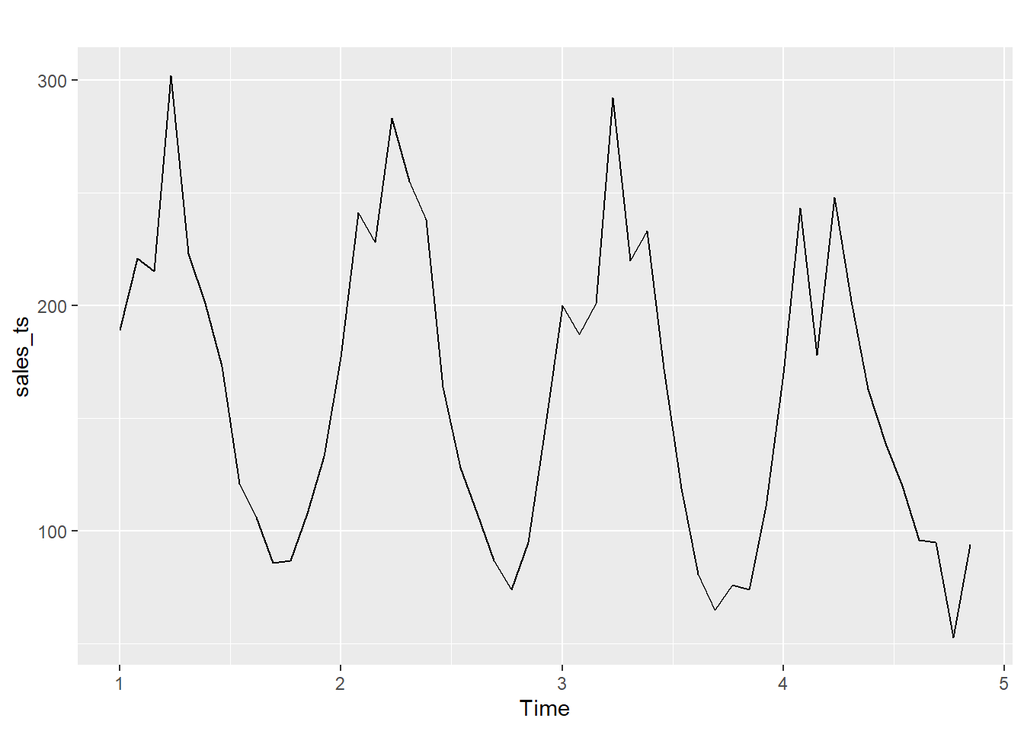

```r
autoplot(sales_ts,facets=TRUE)
```

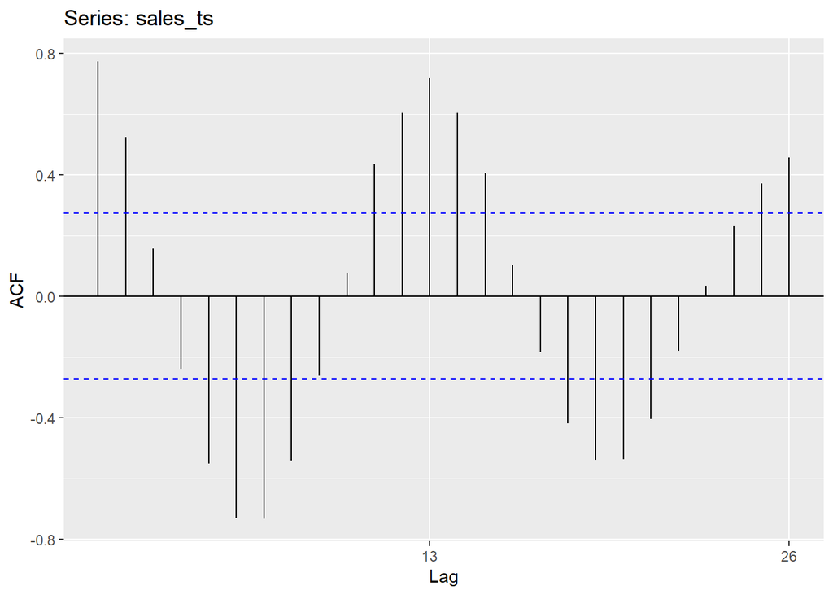

```r
ggAcf(sales_ts)
```

No, it is non-stationary. For a stationary series, we would ultimately expect to see autocorrelations to decay to zero at higher lags (although that is not enough to indicate stationarity). This does not seem to be the case here.

##### (b) Estimate trend and seasonal components for the time series. Do you find evidence of a trend and seasonal component in the data? Explain. Assess the residuals from your decomposition for evidence that they are resulting from a white noise or iid noise process.

###### Compute the trend

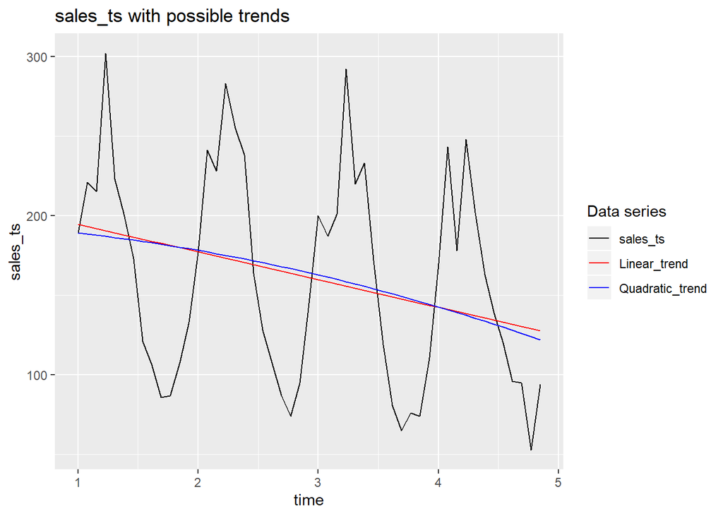

```r
sales_linear <- tslm(sales_ts~trend) ## Fit linear trend

sales_quad<- tslm(sales_ts~trend + I(trend^2)) ## Fit linear trend
sales_with_fits<-cbind(sales_ts,
  Linear_trend = fitted(sales_linear),
  Quadratic_trend = fitted(sales_quad))
autoplot(sales_with_fits)+
  ylab("sales_ts") +
  ggtitle("sales_ts with possible trends") + xlab("time") +
  guides(colour=guide_legend(title="Data series"))+
  scale_colour_manual(values=c("black","red","blue"))
```

There is a strong indication for a trend component which can be linear or quadratic based on the plot above. The two types of trends have very similar behaviours.

(Remove trend)

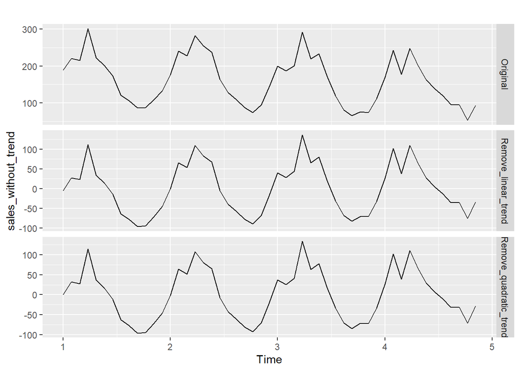

```r
sales_without_trend <- cbind(
  Original = sales_with_fits[,"sales_ts"],
  Remove_linear_trend=sales_ts - sales_with_fits[,"Linear_trend"],
  Remove_quadratic_trend=sales_ts - sales_with_fits[,"Quadratic_trend"])

autoplot(sales_without_trend,facet=TRUE)
```

###### Estimate seasonality

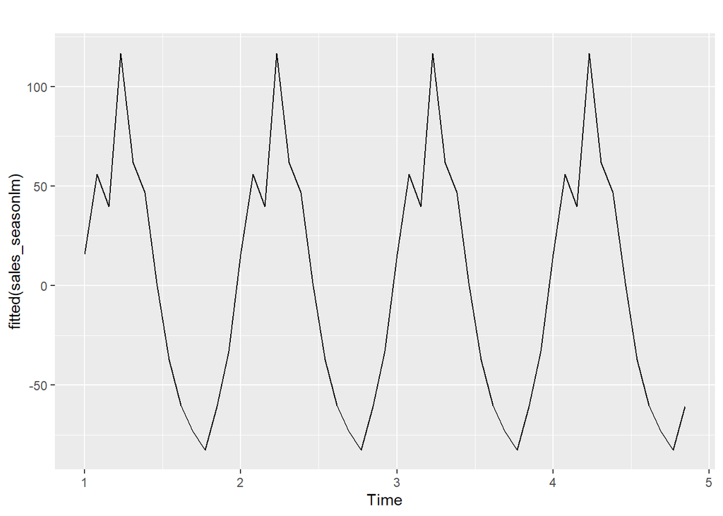

```r
#frequency(sales_without_trend[,"Remove_linear_trend"])
sales_seasonlm <- tslm(Remove_quadratic_trend~season, data = sales_without_trend)
autoplot(fitted(sales_seasonlm))
```

There is also a quite strong seasonality as shown above.

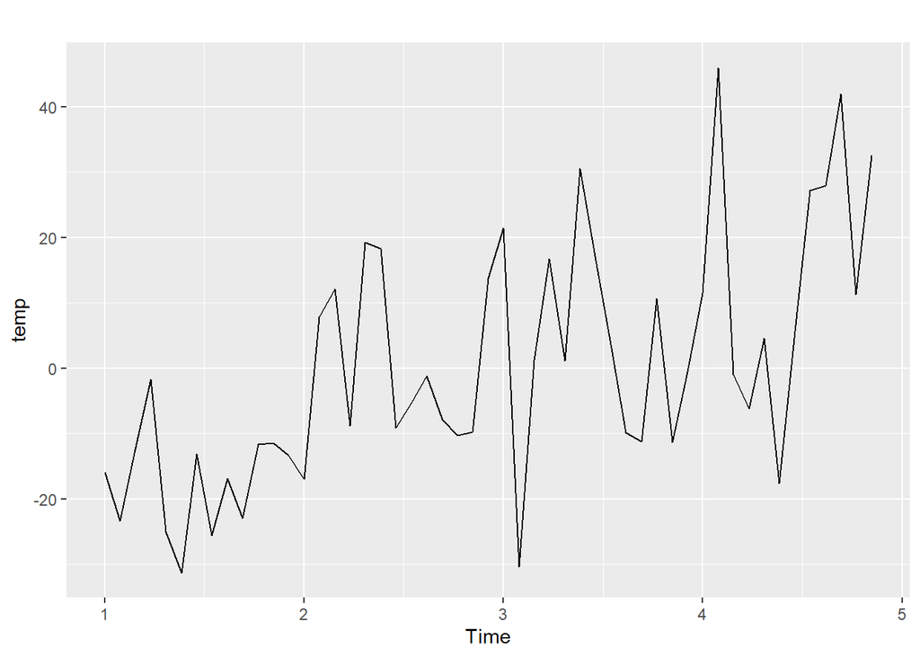

```r
temp <- sales_ts - sales_with_fits[,"Quadratic_trend"] - fitted(sales_seasonlm)
autoplot(temp)
```

##### (c) Using an appropriate sequence of difference operators, try to eliminate any perceived trend and seasonal components from part (c). Assess the residuals from your decomposition for evidence that they are resulting from a white noise or iid noise process.

(using differences)

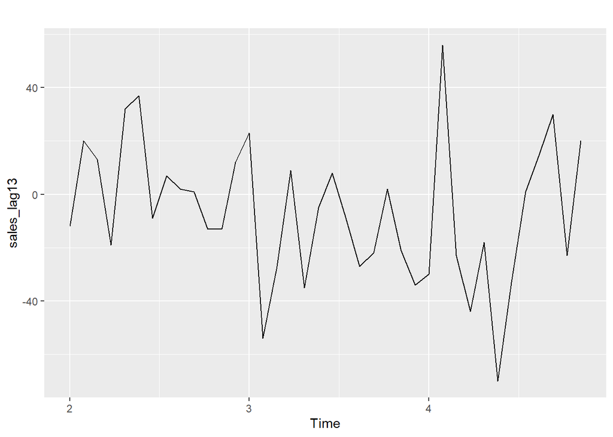

```r
sales_lag13 <- diff(sales_ts,3)
sales_lag13 <- diff(sales_ts,13)
autoplot(sales_lag13)
```